# Feature Engineering I

1/23/2020

## Agenda

1. Data ethics review
2. What is feature engineering?
3. Overview of the ‘caret’ package
4. Parameter selection

## Data ethics review

## Problems

- Demographic data
- Profit optimizing
- Autonomous cars
- Recommendation engines
- Criminal sentencing
- Choice of classification model
- Killer robots

Reasonable people will disagree over subtle matters of right and wrong… thus, the important part of data ethics is committing to *consider* the ethical consequences of your choices.

The difference between “regular” ethics and data ethics is that algorithms scale really easily. Thus, seemingly small decisions can have wide-ranging impact.

## What is feature engineering?

## Setup

```r
knitr::opts_chunk$set(echo = TRUE, message = FALSE, warning = FALSE)
library(tidyverse)
library(caret)
source('theme.R')
wine = read_rds("../resources/wine.rds")
```

## Exploratory visualizations

- Finding interactions
- Looking at correlations
- Assessing distribution of data

## Example

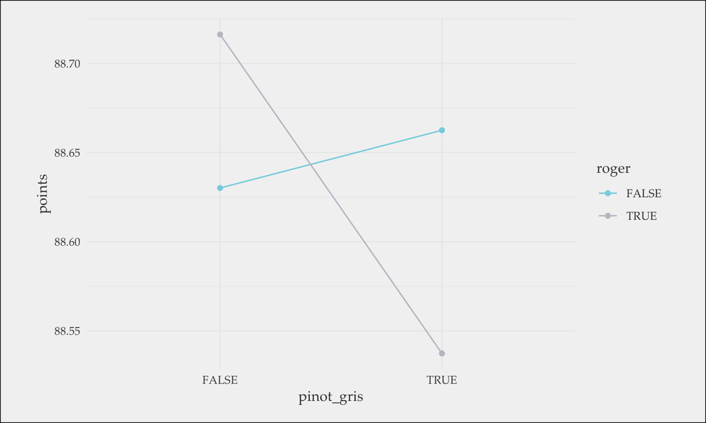

## Example

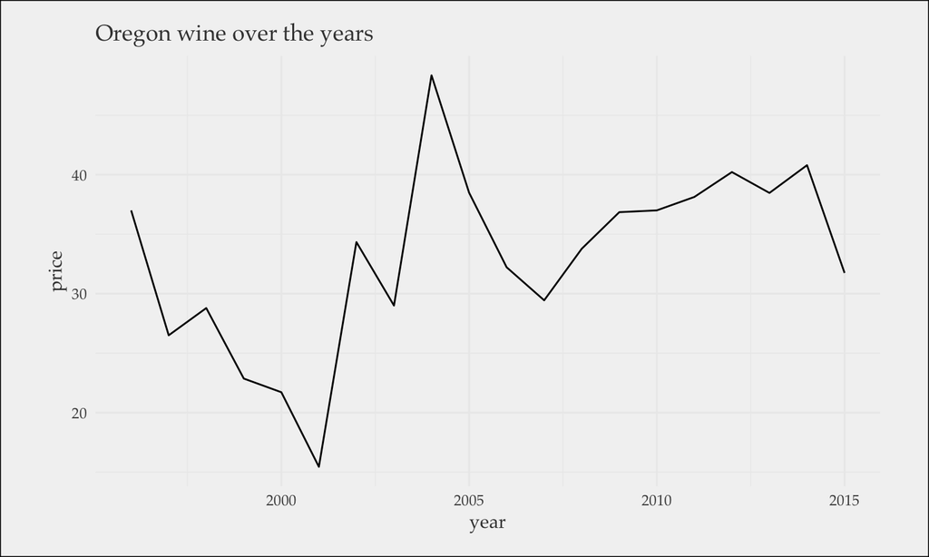

## Encoding categorical predictors: few dummies

```r
library(fastDummies)
wine %>%
  select(taster_name) %>%
  dummy_cols() %>%
  head()
```

| taster_name | taster_name_Roger Voss | taster_name_Paul Gregutt | taster_name_Alexander Peartree | taster_name_Michael Schachner | taster_name_Kerin O’Keefe | taster_name_Anna Lee C. Iijima | taster_name_Virginie Boone | taster_name_Matt Kettmann | taster_name_Sean P. Sullivan | taster_name_Jim Gordon | taster_name_Anne Krebiehl MW | taster_name_Joe Czerwinski | taster_name_Lauren Buzzeo | taster_name_Mike DeSimone | taster_name_Jeff Jenssen | taster_name_Susan Kostrzewa | taster_name_Carrie Dykes | taster_name_Fiona Adams | taster_name_Christina Pickard |
| --- | --- | --- | --- | --- | --- | --- | --- | --- | --- | --- | --- | --- | --- | --- | --- | --- | --- | --- | --- |
| Roger Voss | 1 | 0 | 0 | 0 | 0 | 0 | 0 | 0 | 0 | 0 | 0 | 0 | 0 | 0 | 0 | 0 | 0 | 0 | 0 |
| Paul Gregutt | 0 | 1 | 0 | 0 | 0 | 0 | 0 | 0 | 0 | 0 | 0 | 0 | 0 | 0 | 0 | 0 | 0 | 0 | 0 |
| Alexander Peartree | 0 | 0 | 1 | 0 | 0 | 0 | 0 | 0 | 0 | 0 | 0 | 0 | 0 | 0 | 0 | 0 | 0 | 0 | 0 |
| Paul Gregutt | 0 | 1 | 0 | 0 | 0 | 0 | 0 | 0 | 0 | 0 | 0 | 0 | 0 | 0 | 0 | 0 | 0 | 0 | 0 |
| Michael Schachner | 0 | 0 | 0 | 1 | 0 | 0 | 0 | 0 | 0 | 0 | 0 | 0 | 0 | 0 | 0 | 0 | 0 | 0 | 0 |
| Kerin O’Keefe | 0 | 0 | 0 | 0 | 1 | 0 | 0 | 0 | 0 | 0 | 0 | 0 | 0 | 0 | 0 | 0 | 0 | 0 | 0 |

## Encoding categorical predictors: many dummies

```r
wine %>%
  select(variety) %>%
  mutate(variety=fct_lump(variety,5)) %>%
  dummy_cols() %>%
  head()
```

| variety | variety_Bordeaux-style Red Blend | variety_Cabernet Sauvignon | variety_Chardonnay | variety_Pinot Noir | variety_Red Blend | variety_Other |
| --- | --- | --- | --- | --- | --- | --- |
| Other | 0 | 0 | 0 | 0 | 0 | 1 |
| Other | 0 | 0 | 0 | 0 | 0 | 1 |
| Other | 0 | 0 | 0 | 0 | 0 | 1 |
| Pinot Noir | 0 | 0 | 0 | 1 | 0 | 0 |
| Other | 0 | 0 | 0 | 0 | 0 | 1 |
| Other | 0 | 0 | 0 | 0 | 0 | 1 |

## Other types of engineered factors…

- Words or phrases in text
- A given time period
- An arbitrary numerical cut-off
- Etc.

## Engineering numeric predictors: Box-Cox

Box-Cox transformations use MLE to estimate \(\lambda\)

\(x^{*} = \left\{ \begin{array}{l l} \frac{x^{\lambda}-1}{\lambda\: \tilde{x}^{\lambda-1}}, & \lambda \neq 0 \\ \tilde{x} \: \log x, & \lambda = 0 \\ \end{array} \right.\)

- when \(\lambda=1\), there is no transformation
- when \(\lambda=0\), it is log transformed
- when \(\lambda=0.5\), it is square root
- when \(\lambda=-1\), it is an inverse

## Calculating Box-Cox

```r
x <- as.data.frame(select(wine,price,points))
x_proc <- preProcess(x, method = "BoxCox")
x_proc
```

```
## Created from 89556 samples and 2 variables
##
## Pre-processing:
##   - Box-Cox transformation (2)
##   - ignored (0)
##
## Lambda estimates for Box-Cox transformation:
## -0.3, 1.1
```

```r
x_new <- predict(x_proc, x)
head(x_new)
```

| price | points |
| --- | --- |
| 1.854050 | 87 |
| 1.823113 | 87 |
| 1.789161 | 87 |
| 2.380527 | 87 |
| 1.854050 | 87 |
| 1.882416 | 87 |

## Histogram after Box-Cox

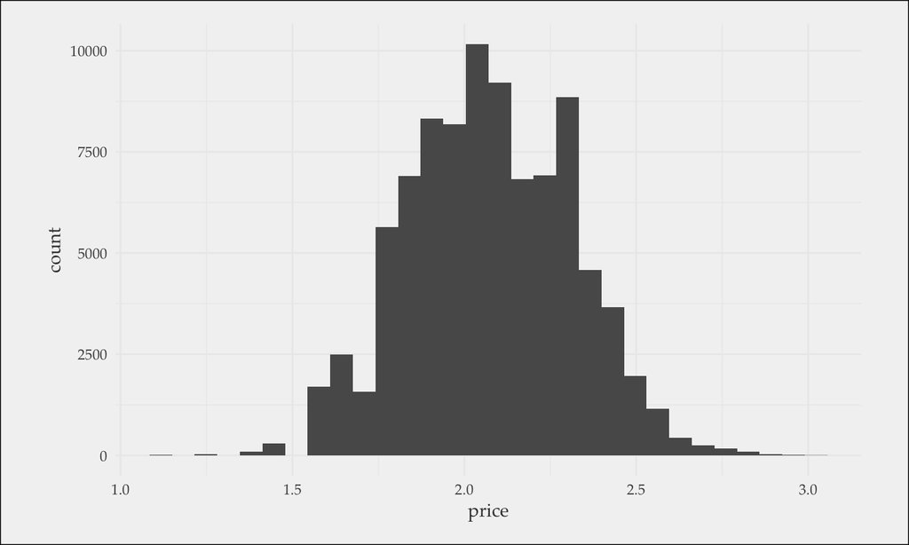

```r
ggplot(x_new,aes(price))+geom_histogram()
```

## Engineering numeric predictors: Standardizing

- mean-centering \(x-\bar{x}\)
- scaling: \(x/std(x)\)

…allows for common scale across variables. Also helps reduce bias when interactions are included (i.e. eliminates variance inflation).

And there are [many other transformations](http://www.feat.engineering/numeric-one-to-many.html) that you can read about.

## Interaction effects

[This chapter](http://www.feat.engineering/detecting-interaction-effects.html) has a good overview of interactions.

- start with domain knowledge
- use visualizations
- 3-way interactions exist, but are rare
- brute force is a last resort

## The ‘caret’ package

## Philosophy

[figure not shown]

## Types of resampling

- [V-fold Cross-Validation](http://www.feat.engineering/resampling.html#cv)
- [Monte Carlo Cross-Validation](http://www.feat.engineering/resampling.html#monte-carlo-cross-validation)
- [The Bootstrap](http://www.feat.engineering/resampling.html#the-bootstrap)

## Typical setup

```r
wino <- wine %>% ## look ma, engineered features!
  mutate(fr=(country=="France")) %>%
  mutate(cab=str_detect(variety,"Cabernet")) %>%
  mutate(lprice=log(price)) %>%
  drop_na(fr, cab) %>%
  select(lprice, points, fr, cab)

wine_index <- createDataPartition(wino$lprice, p = 0.8, list = FALSE)
wino_tr <- wino[ wine_index, ]
wino_te <- wino[-wine_index, ]

set.seed(5004)
lm_fit <- train(lprice ~ .,
                data = wino_tr,
                method = "lm",
                trControl = trainControl(number = 1))
```

Follow [this link](https://topepo.github.io/caret) for the full documentation on caret.

## Train vs. test

```r
lm_fit
```

```
## Linear Regression
##
## 71603 samples
##     3 predictor
##
## No pre-processing
## Resampling: Bootstrapped (1 reps)
## Summary of sample sizes: 71603
## Resampling results:
##
##   RMSE       Rsquared   MAE
##   0.5114613  0.3859124  0.4033647
##
## Tuning parameter 'intercept' was held constant at a value of TRUE
```

```r
wine_pred <- predict(lm_fit, wino_te)
postResample(pred=wine_pred, obs = wino_te$lprice)
```

```
##      RMSE  Rsquared       MAE
## 0.5124344 0.3931137 0.4028655
```

## Exercise (30-40 minutes)

1. Gather in your modeling teams
2. Create 5 new features (in addition to points)
3. Create training and test data
4. Use your new predictors to train a linear regression model
5. Report RMSE on test set

## Parameter selection

## Stepwise selection is bad

Harrell (2015) provides a comprehensive indictment of the method that can be encapsulated by the statement:

> **“… if this procedure had just been proposed as a statistical method, it would most likely be rejected because it violates every principle of statistical estimation and hypothesis testing.”**

Reference: Harrell, F. 2015. Regression Modeling Strategies. Springer.

## Basic model with 11 parameters

```r
wino <- wine %>%
  mutate(country=fct_lump(country,5)) %>%
  mutate(variety=fct_lump(variety,5)) %>%
  mutate(lprice=log(price)) %>%
  select(lprice, points, country, variety) %>%
  drop_na(.)

library(fastDummies)
wino <- dummy_cols(wino, remove_selected_columns = T) %>%
  select(-country_Other, -variety_Other) %>%
  rename_all(funs(tolower(.))) %>%
  rename_all(funs(str_replace_all(., "-", "_"))) %>%
  rename_all(funs(str_replace_all(., " ", "_")))

wine_index <- createDataPartition(wino$lprice, p = 0.8, list = FALSE)
wino_tr <- wino[ wine_index, ]
wino_te <- wino[-wine_index, ]

set.seed(5004)
lm_fit <- train(lprice ~ .,
                data = wino_tr,
                method = "lm",
                trControl = trainControl(number = 1))
```

## Results

```r
lm_fit
```

```
## Linear Regression
##
## 71603 samples
##    11 predictor
##
## No pre-processing
## Resampling: Bootstrapped (1 reps)
## Summary of sample sizes: 71603
## Resampling results:
##
##   RMSE       Rsquared   MAE
##   0.4891515  0.4488954  0.3806915
##
## Tuning parameter 'intercept' was held constant at a value of TRUE
```

```r
wine_pred <- predict(lm_fit, wino_te)
postResample(pred=wine_pred, obs = wino_te$lprice)
```

```
##      RMSE  Rsquared       MAE
## 0.4880510 0.4468570 0.3804876
```

## Recursive feature elimination

[figure not shown]

## Using recursive feature elimination in caret

```r
x <- select(wino_tr,-lprice)
y <- wino_tr$lprice
subsets <- c(1:11)
lmProfile <- rfe(x, y,
                 sizes = subsets,
                 rfeControl = rfeControl(functions = lmFuncs, returnResamp = "all"))
```

## Results

```r
lmProfile
```

```
##
## Recursive feature selection
##
## Outer resampling method: Bootstrapped (25 reps)
##
## Resampling performance over subset size:
##
##  Variables   RMSE Rsquared    MAE   RMSESD RsquaredSD    MAESD Selected
##          1 0.6510  0.01867 0.5201 0.005113   0.013625 0.007404
##          2 0.6368  0.06103 0.5025 0.002298   0.002180 0.001374
##          3 0.6328  0.07283 0.4990 0.002306   0.002321 0.001361
##          4 0.6303  0.08022 0.4978 0.002299   0.002365 0.001436
##          5 0.6255  0.09408 0.4907 0.003552   0.007245 0.005045
##          6 0.6213  0.10623 0.4846 0.002505   0.002763 0.001473
##          7 0.4884  0.44783 0.3793 0.001705   0.002880 0.001258
##          8 0.4876  0.44947 0.3787 0.001678   0.002951 0.001222
##          9 0.4871  0.45065 0.3784 0.001727   0.002903 0.001225
##         10 0.4865  0.45199 0.3778 0.001738   0.002965 0.001266
##         11 0.4859  0.45332 0.3773 0.001728   0.002970 0.001246        *
##
## The top 5 variables (out of 11):
##    country_italy, variety_pinot_noir, variety_cabernet_sauvignon, variety_bordeaux_style_red_blend, country_portugal
```

## Coefficients

```r
lmProfile$fit
```

```
##
## Call:
## lm(formula = y ~ ., data = tmp)
##
## Coefficients:
##                      (Intercept)                     country_italy
##                         -8.46192                           0.33462
##               variety_pinot_noir        variety_cabernet_sauvignon
##                          0.32773                           0.27115
## variety_bordeaux_style_red_blend                  country_portugal
##                          0.19336                          -0.16159
##                       country_us                            points
##                          0.15723                           0.13064
##                   country_france                     country_spain
##                          0.11276                           0.10281
##               variety_chardonnay                 variety_red_blend
##                          0.09754                           0.09101
```

## Graphing performance gains

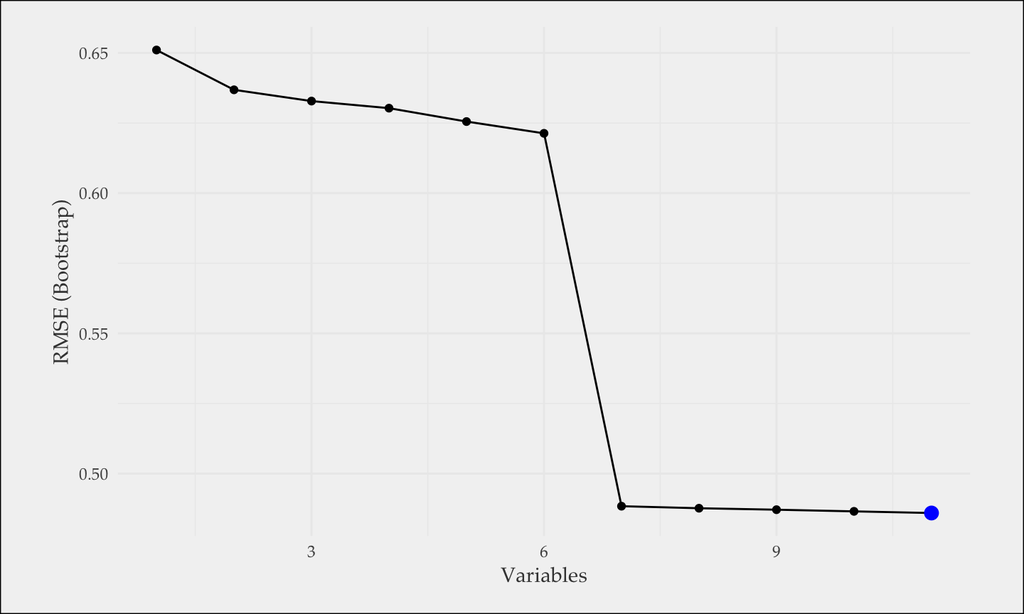

```r
ggplot(lmProfile)
```

## Visualizing the resampling

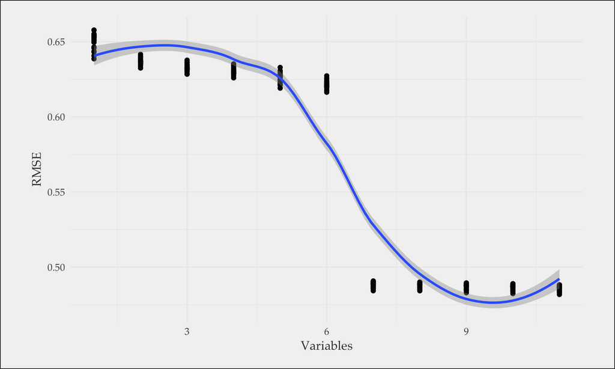

```r
lmProfile[["resample"]] %>%
  ggplot(aes(Variables, RMSE))+
  geom_point()+
  geom_smooth()
```